# Level Analysis

Janette Avelar

5/23/2022

# Cycle 5 (6.17.22)

Guiding questions/tasks & format:  
`SCHOOL TYPE`: How do tagging patterns differ among district, charter, independent, sws, virtual, microschool, homeschool, and hub schools?  
* table of biggest differences between categories  
* odds ratio  
* visualization

## Analysis Notes:

**Independent cases** * district = 78  
* charter = 57  
* independent = 20  
* sws = 5  
* virtual = 9  
* microschool = 12  
* homeschool = 5  
* hub = 3

**Multicoded cases** * district AND charter = 4  
* district AND sws = 5  
* district AND virtual = 7  
* district AND microschool = 1  
* district AND homeschool = 1  
* charter AND sws = 1  
* charter AND virtual = 2  
* charter AND hub = 1  
* independent AND virtual = 1  
* independent AND microschool = 7  
* independent AND hub = 1  
* sws AND virtual = 1  
* sws AND microschool = 1  
* virtual AND microschool = 1  
* virutal AND homeschool = 1  
* virtual AND hub = 1  
* microschool AND homeschool = 1  
* microschool AND hub = 1 * NONE = 5  
* Boston Day And Evening Academy  
* CodeRVA Regional High School  
* The Metropolitan Regional Career And Technical Center  
* Grant Beacon Middle School  
* Utah Schools For The Deaf  
* 0 `NA` values * total schools = 161 (5 `NA` manually recoded)

*Focus on odds ratio plot for levels by Tuesday–other plots by this weekend*

Further cleaning needed. Multi-coded and non-coded data:

Paring down to district, charter, and independent  
* charter = 58  
* district = 77  
* independent/other = 26

## Table of Differences

|  | Tag | District vs. Charter Difference | Charter vs. Independent Difference | Independent vs. District Difference | Pct. Tags Within (District) | Pct. Tags Within (Charter) | Pct. Tags Within (Independent) | Pct. Tags Across (District) | Pct. Tags Across (Charter) | Pct. Tags Across (Independent) | N Tags (District) | N Tags (Charter) | N Tags (Independent) |
| --- | --- | --- | --- | --- | --- | --- | --- | --- | --- | --- | --- | --- | --- |
| 1 | social-emotional skills assessments | 12.65% | 8.36% | 4.3% | 64.94% | 77.59% | 69.23% | 31.06% | 27.95% | 11.18% | 50 | 45 | 18 |
| 2 | students as co-leaders | 3.2% | 44.96% | 41.76% | 42.86% | 39.66% | 84.62% | 20.5% | 14.29% | 13.66% | 33 | 23 | 22 |
| 3 | teachers as co-leaders | 12.4% | 19.1% | 6.69% | 77.92% | 65.52% | 84.62% | 37.27% | 23.6% | 13.66% | 60 | 38 | 22 |
| 4 | deeper learning assessments | 3.36% | 2.79% | 6.14% | 79.22% | 75.86% | 73.08% | 37.89% | 27.33% | 11.8% | 61 | 44 | 19 |
| 5 | flexible staffing &amp; alternative teaching roles | 11.82% | 15.65% | 27.47% | 57.14% | 68.97% | 84.62% | 27.33% | 24.84% | 13.66% | 44 | 40 | 22 |
| 6 | interdisciplinary | 5.28% | 5.31% | 10.59% | 74.03% | 79.31% | 84.62% | 35.4% | 28.57% | 13.66% | 57 | 46 | 22 |
| 7 | makerspace | 16.57% | 33.95% | 17.38% | 44.16% | 27.59% | 61.54% | 21.12% | 9.94% | 9.94% | 34 | 16 | 16 |
| 8 | peer to peer support | 0.63% | 10.21% | 10.84% | 54.55% | 55.17% | 65.38% | 26.09% | 19.88% | 10.56% | 42 | 32 | 17 |
| 9 | place-based learning | 1.1% | 22.68% | 23.78% | 45.45% | 46.55% | 69.23% | 21.74% | 16.77% | 11.18% | 35 | 27 | 18 |
| 10 | portfolios and public exhibitions | 1.16% | 11.8% | 10.64% | 70.13% | 68.97% | 80.77% | 33.54% | 24.84% | 13.04% | 54 | 40 | 21 |

[output cut: 62 more lines]

# Largest Differences

## District vs. Charter Barchart

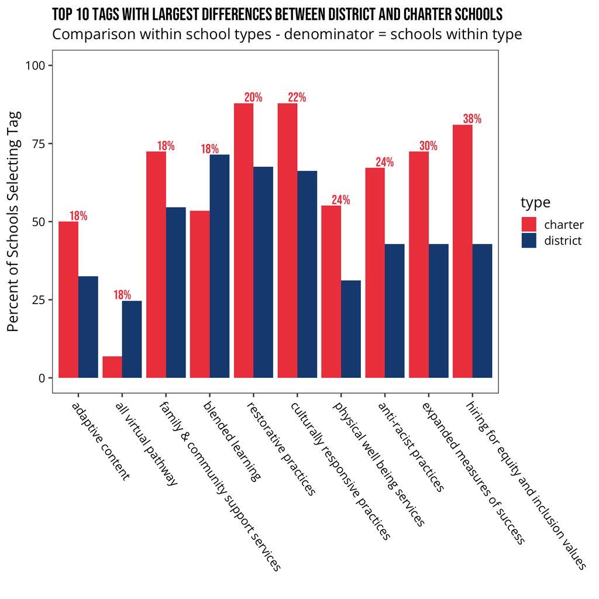

## Charter vs. Independent

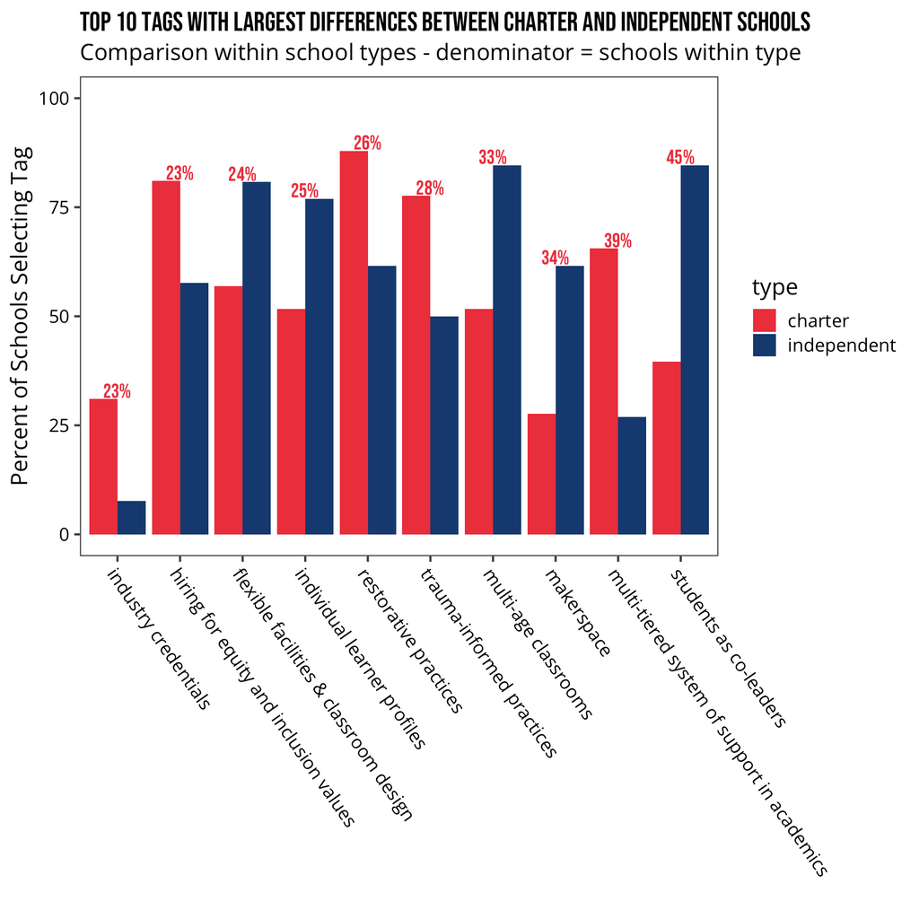

## Independent vs. District Barchart

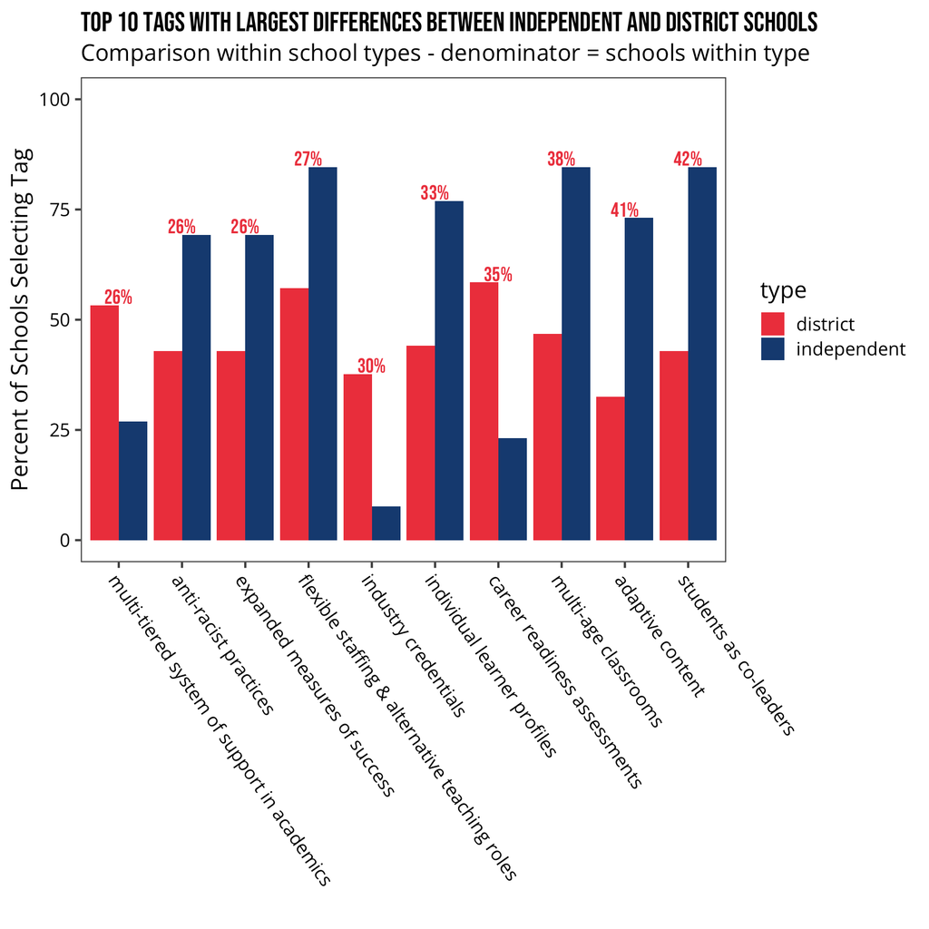

# Individual Type Analysis

## Charter vs. non-Charter Bar Chart

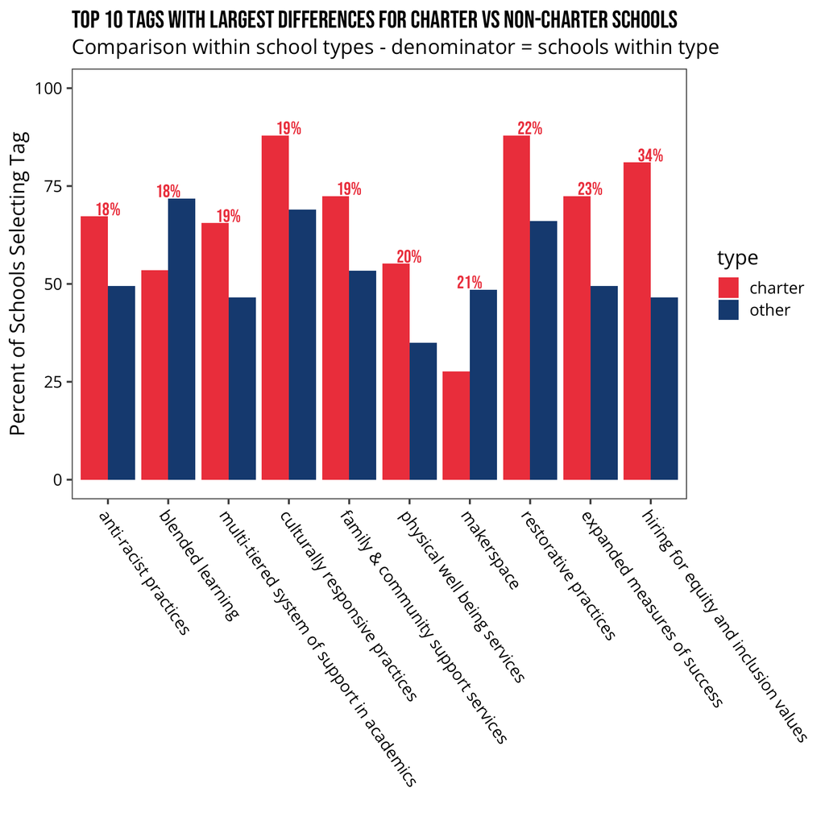

## District vs. non-District Barchart

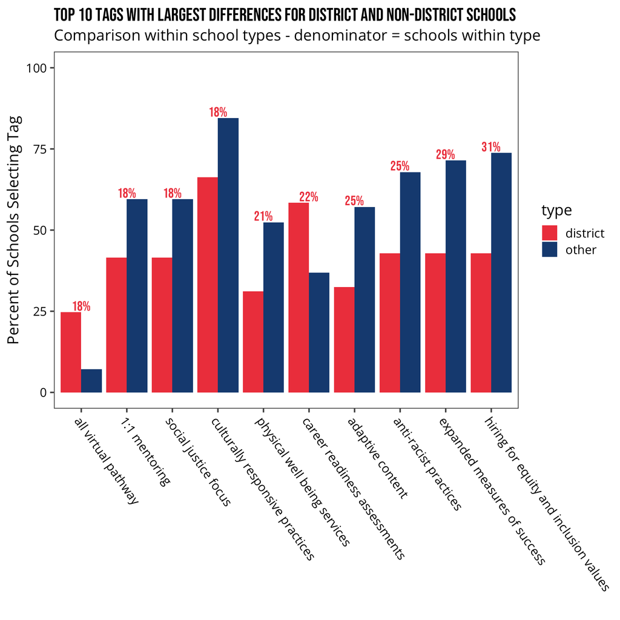

## Independent vs. non-Independent Barchart

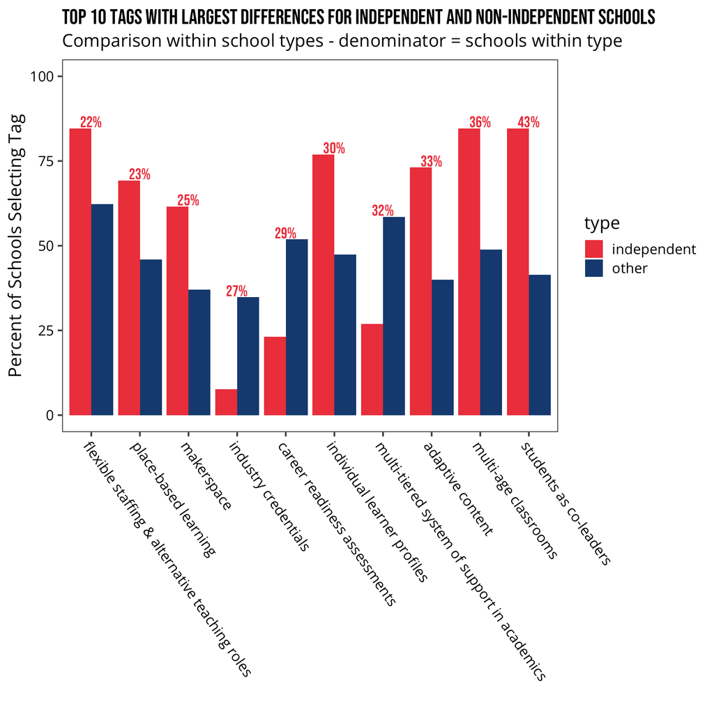

# Variation Across All Types

## Variability Between All School Types

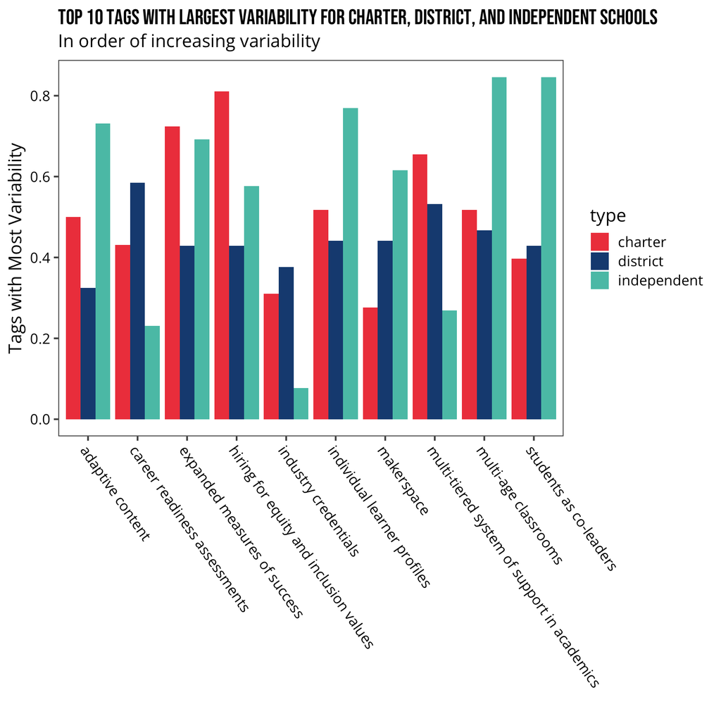

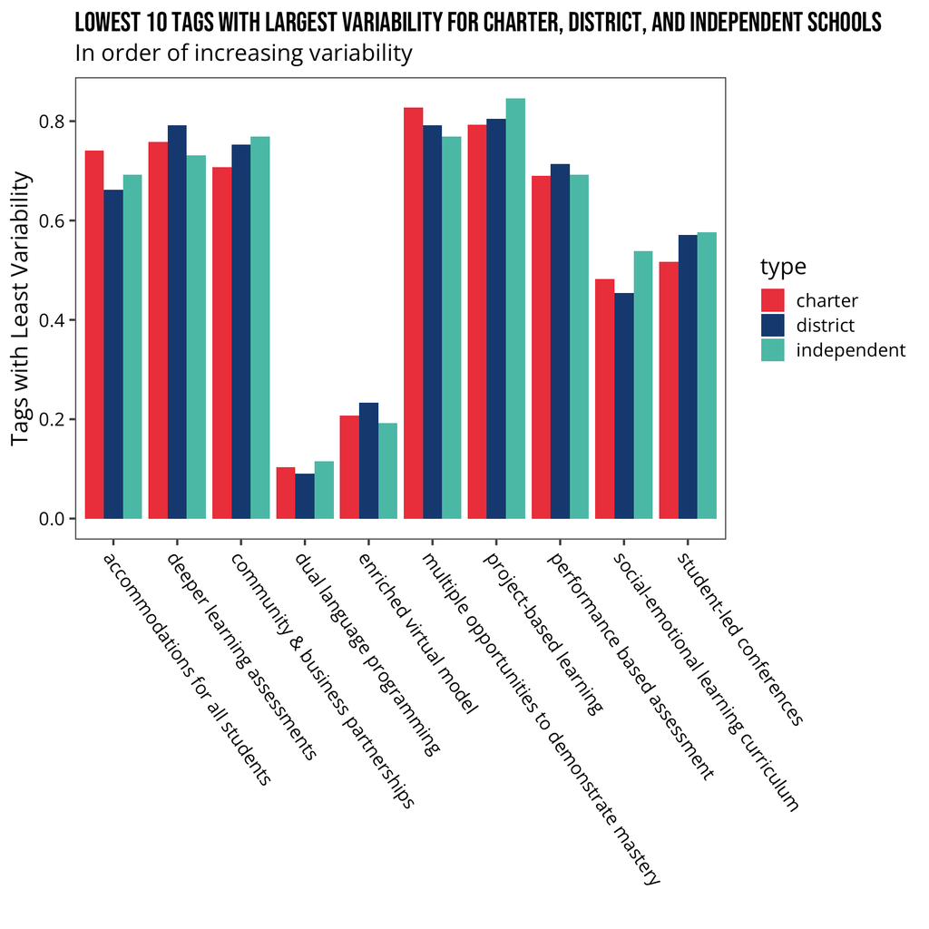

Save plots: